# How to Make Publication-Quality Maps with R

11.15.2019

## Today's workshop

- **Introduction**
- **Workflow**
- **Questions**

## Expectations for this workshop

- **Prereqs**
  - Basic knowledge of R
  - RStudio installed on your machine
  - The following packages: tidyverse, ggplot2, sf, ggspatial
- **Helpful but not required**
  - Familiarity with the tidyverse and ggplot2
  - Experience with GIS

## Objectives

- **You'll leave with…**
  - An example map using vector data
  - Code you can adapt for your own projects
- **We won't cover…**
  - Geospatial analysis
  - Raster data

## Why use R for map-making?

- **Advantages**
  - Free and open-source
  - Easy to integrate with your R projects
  - Modifiable - make tweaks, toggle layers
  - Modulable - spin out figures for different end-points
- **Disadvantages**
  - Need to script changes, can't just point-and-click
  - Some features difficult to integrate (e.g., basemaps)

## Example 1.

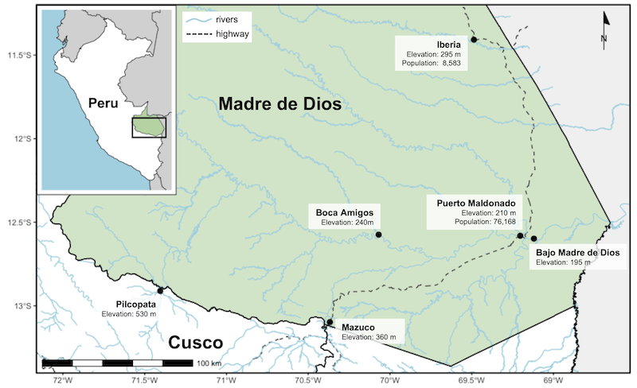

Example 1: Study sites in Madre de Dios, Peru

From [Gonzalez et al. 2019](https://www.sciencedirect.com/science/article/pii/S0013935119305833?via%3Dihub)

## Example 2.

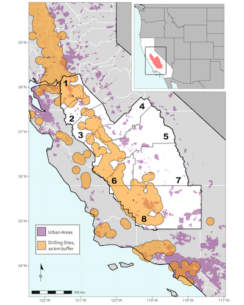

Example 2. Oil and gas preproduction in California

From Gonzalez et al. *in review*

## Map-making in R is like…

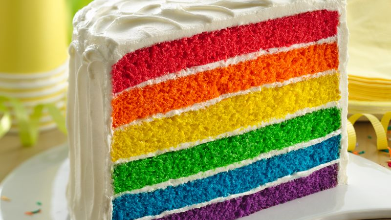

bettycrocker.com

…making a layered cake. It's also a piece of cake, once you have the basics down.

## Workflow

1. **Ideate** - Sketch out what you want, get feedback
2. **Gather** - Gather the data you need
3. **Set up** - Set up your R workspace
4. **Prepare** - Prepare the data
5. **Visualize** - Visualize the features you're interested in
6. **Order** - Decide on order of layers
7. **Construct** - Map each layer, one at a time
8. **Stack** - Put the layers together
9. **Style** - color, texture, details, axes, scale bar, north arrow
10. **Finalize** - labels, other finishing touches
11. **Share**

## 1. Ideate

- Sketch out what you want
- Get feedback
- We'll skip this for today's purposes, but helpful to do before putting in the time to code!
- For today's workshop, let's make a map that shows census tracts by CalEnviroScreen score overlaid with air quality monitor points, showing magnitude of fine particulate matter (PM2.5)

## 2. Gather

- Identify the datasets you need
- Your data (whatever you're working on and want to share)
- Cities, landmarks, administrative boundaries (counties, states/provinces, countries), etc.
- For today's workshop, we'll use the following datasets:
  - Shapefile data from the California Communities Environmental Health Screening Tool, [CalEnviroScreen 3.0](https://oehha.ca.gov/calenviroscreen/report/calenviroscreen-30)
  - Locations of air quality monitors from the [California Air Resources Board (CARB)](https://ww3.arb.ca.gov/html/ds.htm)
  - Mapping files for administrative boundaries from the [U.S. Census Bureau](https://www.census.gov/geographies/mapping-files.html)

## 3. Set up

- Open up RStudio
- Start a directory with your R script, add the data
- Load the relevant packges (and install them if you haven't already)

```r
# if you don't have the packages below installed, use this line
#install.packages(c("tidyverse", "ggplot2", "sf", "ggspatial", "viridis"))

# loads relevant packages
library(tidyverse)  # broad range of functions for data manipulation
library(ggplot2)    # for plotting (fyi, included in 'tidyverse')
library(sf)         # useful package for GIS operations
library(ggspatial)  # for adding map scales, north arrow
library(viridis)    # color-blind friendly color palettes
```

## 4. Prepare

- Download data for the workshop from [this GitHub repo](https://github.com/djxgonzalez/workshop-publication-quality-maps-R)
- Define coordinate reference system (CRS)
- Import the data

```r
# defines coordinate reference system (CRS), for map projection
project_crs <- st_crs("+init=epsg:4269 +proj=longlat +ellps=GRS80
                       +datum=NAD83 +no_defs +towgs84=0,0,0")

# imports the datasets and matches all coordinate reference systems
cal_enviro <- st_read("data/cal_enviro.shp") %>% st_transform(project_crs)
cal_counties <- st_read("data/cal_counties.shp") %>% st_transform(project_crs)
carb_monitors <- st_read("data/carb_monitors.shp") %>% st_transform(project_crs)
us_states <- st_read("data/us_states.shp") %>% st_transform(project_crs)
world_countries <- st_read("data/world_countries.shp") %>% st_transform(project_crs)
```

## 5. Visualize

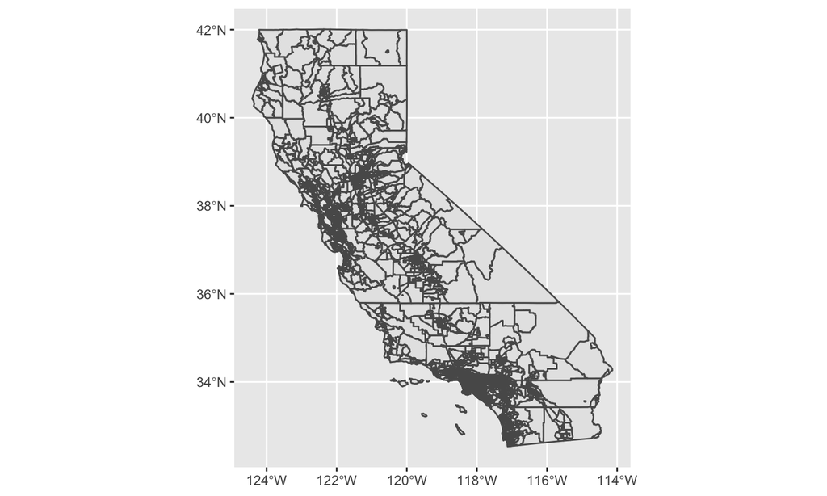

```r
# plots the data we have, e.g., census tract polygons, to make sure it looks right
ggplot() +
  geom_sf(data = st_geometry(cal_enviro))
```

```r
# note: 'geom_sf()' is a ggplot geom specifically for sf objects, i.e.,
#       spatial features imported using the 'sf' package
# note: 'st_geometry()' strips everything but the vector data
```

## 5. Visualize, part 2

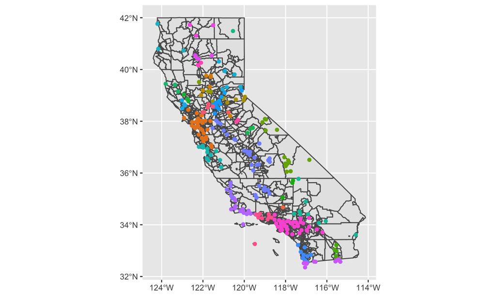

```r
# adds layer with location of CARB air quality monitors to census tracts
ggplot() +
  geom_sf(data = st_geometry(cal_enviro)) +
  geom_sf(data = carb_monitors, aes(color = AIRDISTRIC)) + # color by air district
  theme(legend.position = "none") # drops legend (we don't need it right now)
```

```r
# note: notice how we need to point to a different data source within each
#       'geom_sf' call; if we define a data source within the ggplot() call,
#       the layering won't work
```

## 6. Order

- Decide on order of layers
- For this map, let's do the following (in order):
  - Layer 1: neighboring states (as basemap)
  - Layer 2: neighboring country (also as basemap)
  - Layer 3: census tracts shaded by CalEnviroScreen decilee
  - Layer 4: outline of California state boundary
  - Layer 5: points for air monitors with size linked to mean PM2.5 concentration

## 7. Construct

```r
# Map each layer, one at a time.  It's a good idea to plot each layer
# to make sure it looks right this is redundant for some of the layers,
# but I find it helpful to have a consistent naming system, e.g.,
# when working with the data for other purposes

# layer - census tracts in the top 10% for CalEnviroScreen score; these
#         are defined as 'environmental justice' communities in this dataset
  lyr_cal_enviro <- cal_enviro %>% select(CIdecile)
# layer - air quality monitors points data; let's spatially join these data
#         to the 'cal_enviro' dataset (a step that's outside the scope of this
#         workshop) so we can manipulate the size by mean PM2.5 pollution levels
  lyr_monitors <- carb_monitors %>% st_join(cal_enviro) %>% select(pmP) %>% drop_na()
# layer - California state boundary; binds counties together
  lyr_california <- cal_counties %>% st_union() %>% st_geometry()
# layer - states
  lyr_states <- us_states %>%
    filter(NAME %in% c("Oregon", "Idaho", "Nevada", "Arizona", "Utah")) %>%
    st_geometry()
# layer - world countries (for map inset)
  lyr_countries <- world_countries %>%
    filter(CNTRY_NAME %in% c("Mexico")) %>%
    st_geometry()
```

## 8. Stack

```r
# put the layers together!
my_map <-  ggplot() +
  # layer 1 - neighboring states shaded gray with slightly darker outline
  geom_sf(data = lyr_states, fill = "gray80", color = "gray70") +
  # layer 2 - neighboring country, shaded darker gray with slightly darker outline
  geom_sf(data = lyr_countries, fill = "gray60", color = "gray50") +
  # layer 3 - census tracts shaded by CalEnviroScreen decile
  geom_sf(data = lyr_cal_enviro, aes(fill = as.factor(CIdecile)), color = NA) +
  scale_fill_viridis(alpha = 0.6, discrete = TRUE) +
  # layer 4 - outline of California state boundaries with black border
  geom_sf(data = lyr_california, fill = NA, color = "#000000") +
  # layer 5 - air monitors with size determined by PM2.5 percentile
  geom_sf(data = lyr_monitors, aes(size = pmP), alpha = 0.15) +
  # sets x-axis (longitude) and y-axis (latitude) viewer range
  xlim(c(-125, -114)) + ylim(c(32.2, 42.2)) +
  # makes the negative space (i.e., background) blue
  theme(panel.grid = element_line(color = "#ADD8E6"),
        panel.background = element_rect(fill = "#ADD8E6"),
        legend.position = "none") # drops legend (we don't need it right now))
```

## 8. Stack, part 2

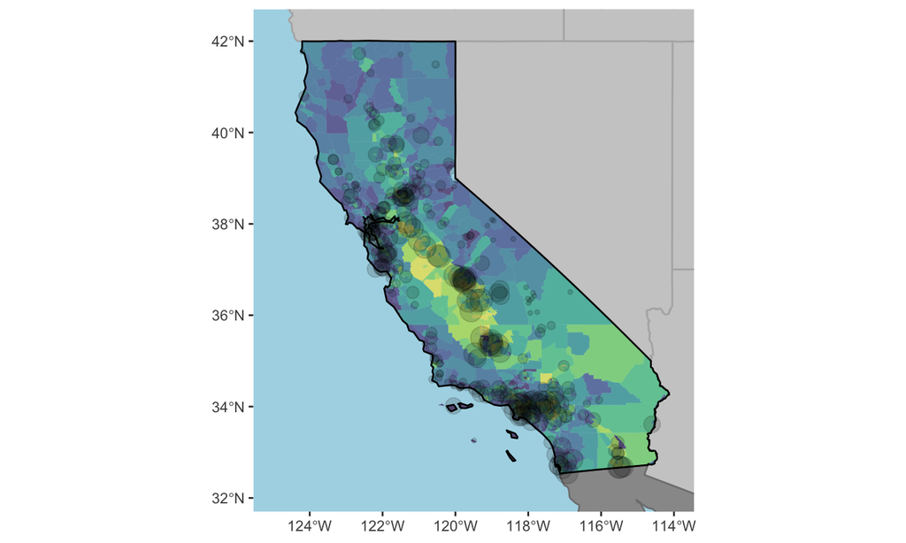

## 9. Style

Let's add details like a scale bar and north arrow

```r
my_map <- my_map +
  # adds scale bar to bottom left ('bl')
  annotation_scale(location = "bl", width_hint = 0.4) +
  # adds north arrow top right ('tr')
  annotation_north_arrow(location = "tr", which_north = "true",
                         style = north_arrow_minimal) +
  theme_bw() + # adds outline to panel
  # need to add this code again as it was nullified by the above line
  theme(panel.grid = element_line(color = "#ADD8E6"),
        panel.background = element_rect(fill = "#ADD8E6"),
        legend.position = "none") # drops legend (we don't need it right now))
```

## 9. Style, part 2

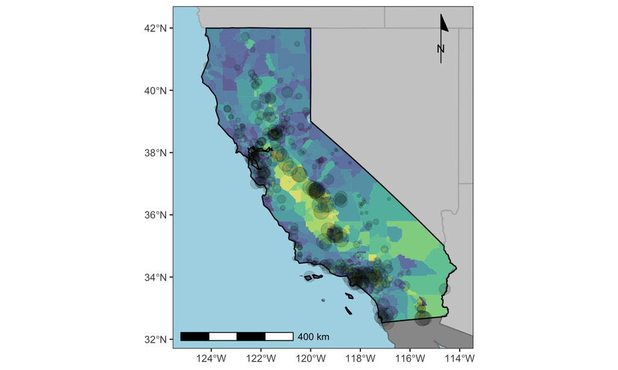

## 10. Finalize

- Add labels, position legend, other finishing touches
- Place map inset, highlight area of focus
- Can be difficult to get *just right* with R
- A vector graphics editor is great for this
- E.g., [Adobe Illustrator](https://www.adobe.com/products/illustrator.html), [InkScape](https://inkscape.org/) (free alternative)

## 11. Share

- Share your work!
- Manuscripts
- Presentations
- Personal website, Twitter, Tiktok, idk

## Resources

- [Stanford Geospatial Center](https://library.stanford.edu/research/stanford-geospatial-center)
- [Stanford Library Workshops](https://library.stanford.edu/workshops)
- [Stanford R Community](https://library.stanford.edu/projects/r)
- [Geocomputation with R](https://geocompr.robinlovelace.net/) (free online book)
- StackOverflow, GitHub, other forums

## Thank you!

### How to Make Publication-Quality Maps with R

**David J.X. Gonzalez,** david.gonzalez@stanford.edu

PhD Candidate, Emmett Interdisciplinary Program in Environment and Resources (E-IPER), Stanford Earth

11.15.2019

**[davidjxgonzalez.me](http://www.davidjxgonzalez.me/)**